# CS5950/CS4950/CS3950 Course Project Q7

## Name: Dac Vinh Nguyen

## ID: 101113852

This project recaps and systematises work that has been done in the exercise notebooks: if you have worked through the notebooks, little extra work is required. The aim of the project is to give you the experience of trying to develop a neural network classifier (or regressor), involving setting up a model, optimising the amount of regularisation, investigating its performance, and devising a new model.

You should do your work in this notebook, filling in the sections below. To do the work, you may re-use code from **any of the lab-session sheets provided so far**. (In fact, you should be able to do nearly the entire project using code taken from previous lab sessions.)

Please complete this workbook and submit it on Moodle together with answers for other questions, with all outputs (numbers and graphs) visible and included.

Please write your student number **here**:  
so that I have an identifier of which worksheet I am marking, to prevent any confusion! (I have to download your notebooks before marking them, so I don't want to accidentally give credit for your notebook to somebody else...)

## Set up dataset

You may choose any of the datasets included with Pytorch, or used in the course so far (including, for example, the percolation data). (It is a free country and you may use any other data you wish.)

A safe choice would be either the MNIST data or the MNIST-fashion data, which is a drop-in replacement for MNIST (same size data format, same number of classes, same number of training and test examples).

A more interesting choice would be CIFAR-10

In setting up the data, you should set up a training set and a test set. The test set should be large enough to give a reasonably accurate assessment of the error-rate (or loss) of your models: preferably at least 10,000 examples.

For the learning curve experiment (below), you will need to construct training sets of different sizes, with the largest at least 10 times the smallest. For the MNIST data, for example, your smallest training set might be 500, with sizes 500, 1000, 2000, 4000, 8000, 16000, 32000, and perhaps 60000 if you have time. (You get no extra marks for doing very long experiments.)

## Set up model

Set up a Pytorch model (you may find it helpful to keep it simple and fast to train). Train on an intermediate-sized dataset (if you are using MNIST, say 2000 or 4000).

Plot the loss and error rate as a function of training epochs.

### 1. Assessment of initial model: **12 marks**

Ensure that your model is complex enough to *overfit* the training data: that is the loss/error-rate on the training set should be below your target loss/error-rate, and the loss/error-rate on the validation set should be higher than this (preferably higher than your target error-rate).

```
Full training set: 60000 examples
Training subset: 4000 examples
Test set: 10000 examples
```

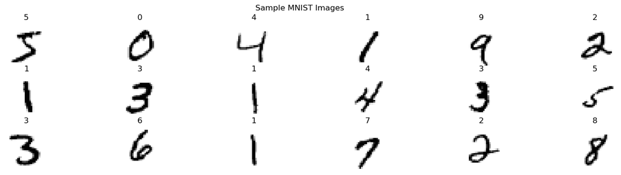

```
Training FC_Model (784->256->128->10) on 4000 examples, no regularisation...
Expecting overfitting: training loss/error < validation loss/error

Epoch 10 loss: 0.019 acc: 0.997 val_loss: 0.257 val_acc: 0.933
Epoch 20 loss: 0.001 acc: 1.000 val_loss: 0.294 val_acc: 0.938
Epoch 30 loss: 0.000 acc: 1.000 val_loss: 0.326 val_acc: 0.939
Epoch 40 loss: 0.000 acc: 1.000 val_loss: 0.352 val_acc: 0.939
Epoch 50 loss: 0.000 acc: 1.000 val_loss: 0.372 val_acc: 0.939
```

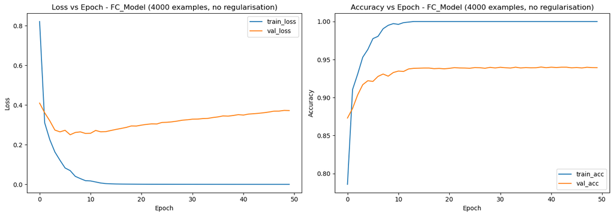

```
============================================================
Assessment of Initial Model (FC_Model)
============================================================
Final Training Loss:    0.0001
Final Validation Loss:  0.3723
Final Training Acc:     1.0000
Final Validation Acc:   0.9393

Overfitting confirmed:
  Training loss (0.0001) < Validation loss (0.3723)
  Training error (0.0000) < Validation error (0.0607)

The model has sufficient complexity to overfit the 4000 training examples.
The gap between training and validation performance indicates overfitting,
which motivates the regularisation experiment in Q2.
```

```python
# ==================================================================
# Q1: Set up dataset, model, and demonstrate overfitting (12 marks)
# ==================================================================
# Code sources:
# - Imports, data loading, loss, validation: Week3Exercise1_MNIST_CNN.ipynb
# - Model pattern, training function, plotting: Week3Exercise2_Percolation_CNN.ipynb
# ==================================================================

# --- Imports (from Week3Exercise1 + Week3Exercise2) ---
import numpy as np
import matplotlib.pyplot as plt
import matplotlib.cm as cm
%matplotlib inline

import torch
import torch.nn as nn
import torch.nn.functional as F
import torchvision
import torchvision.datasets as datasets
from torchvision import transforms
import torch.optim as optim

# --- Load MNIST Data (from Week3Exercise1) ---
transform_list = transforms.Compose([transforms.ToTensor(), transforms.Normalize(mean=[0.0], std=[1.0,])])
mnist_trainset = datasets.MNIST(root='./data', train=True, download=True, transform=transform_list)
mnist_testset = datasets.MNIST(root='./data', train=False, download=True, transform=transform_list)

# Intermediate training subset of 4000 examples (from Week3Exercise1)
mnist_trainset_4000 = [mnist_trainset[i] for i in range(0, 4000)]

print(f"Full training set: {len(mnist_trainset)} examples")
print(f"Training subset: {len(mnist_trainset_4000)} examples")
print(f"Test set: {len(mnist_testset)} examples")

# --- Visualise sample images (from Week3Exercise1: plot_images) ---
def plot_images(images_to_plot, titles=None, ncols=6, thefigsize=(18, 4)):
    n_images = images_to_plot.shape[0]
    nrows = np.ceil(n_images / ncols).astype(int)
    fig, ax = plt.subplots(nrows, ncols, sharex=True, sharey=True, figsize=thefigsize)
    ax = ax.flatten()
    for i in range(n_images):
        ax[i].imshow(images_to_plot[i, 0, :, :].reshape(28, 28), cmap=cm.Greys)
        ax[i].axis('off')
        if titles is not None:
            ax[i].set_title(titles[i])

images_to_plot = np.array([mnist_trainset_4000[i][0].numpy() for i in range(0, 18)])
titles = [mnist_trainset_4000[i][1] for i in range(0, 18)]
plot_images(images_to_plot, titles)
plt.suptitle('Sample MNIST Images')
plt.show()

# --- Loss Function (from Week3Exercise1) ---
loss_function = nn.CrossEntropyLoss()

# --- Accuracy and Loss (from Week3Exercise2, adapted for multiclass using Week3Exercise1's torch.max) ---
def accuracy_and_loss(net, loss_function, dataloader):
    total_correct = 0
    total_loss = 0.0
    total_examples = 0
    n_batches = 0
    with torch.no_grad():
        for data in dataloader:
            images, labels = data
            outputs = net(images)
            batch_loss = loss_function(outputs, labels)
            n_batches += 1
            total_loss += batch_loss.item()
            _, predicted = torch.max(outputs, dim=1)
            total_correct += (predicted == labels).sum().item()
            total_examples += labels.size(0)
    accuracy = total_correct / total_examples
    mean_loss = total_loss / n_batches
    return (accuracy, mean_loss)

# --- Training function (from Week3Exercise2: define_and_train, adapted for multiclass) ---
def define_and_train(NN_class, n_epochs, training_set, test_set, batch_size=32, weight_decay=0.0):
    trainloader = torch.utils.data.DataLoader(training_set, batch_size=batch_size, shuffle=True)
    testloader = torch.utils.data.DataLoader(test_set, batch_size=batch_size, shuffle=True)

    thenet = NN_class()
    optimizer1 = optim.Adam(thenet.parameters(), weight_decay=weight_decay)

    train_acc = []
    val_acc = []
    train_loss = []
    val_loss = []

    for epoch in range(n_epochs):
        total_loss = 0
        total_correct = 0
        total_examples = 0
        n_mini_batches = 0

        for i, mini_batch in enumerate(trainloader, 0):
            images, labels = mini_batch
            optimizer1.zero_grad()
            outputs = thenet(images)
            loss = loss_function(outputs, labels)
            loss.backward()
            optimizer1.step()

            n_mini_batches += 1
            total_loss += loss.item()
            _, predicted = torch.max(outputs, dim=1)
            total_correct += (predicted == labels).sum().item()
            total_examples += labels.size(0)

        epoch_training_accuracy = total_correct / total_examples
        epoch_training_loss = total_loss / n_mini_batches
        epoch_val_accuracy, epoch_val_loss = accuracy_and_loss(thenet, loss_function, testloader)

        if (epoch + 1) % 10 == 0:
            print('Epoch %d loss: %.3f acc: %.3f val_loss: %.3f val_acc: %.3f'
                  % (epoch + 1, epoch_training_loss, epoch_training_accuracy, epoch_val_loss, epoch_val_accuracy))

        train_loss.append(epoch_training_loss)
        train_acc.append(epoch_training_accuracy)
        val_loss.append(epoch_val_loss)
        val_acc.append(epoch_val_accuracy)

    history = {'train_loss': train_loss, 'train_acc': train_acc, 'val_loss': val_loss, 'val_acc': val_acc}
    return (history, thenet)

# ====================================================================
# Model 1: Fully-Connected Network
# Architecture from Week3Exercise2's NN_two_hidden, adapted for MNIST:
# - Input: 784 (28x28 flattened) instead of 64
# - Output: 10 classes instead of 1 (removed Sigmoid, using CrossEntropyLoss)
# - Larger hidden layers (256, 128) to ensure overfitting capacity
# ====================================================================
class FC_Model(nn.Module):
    def __init__(self):
        super(FC_Model, self).__init__()
        self.layers = nn.Sequential(
            nn.Flatten(),
            nn.Linear(784, 256),
            nn.ReLU(),
            nn.Linear(256, 128),
            nn.ReLU(),
            nn.Linear(128, 10))

    def forward(self, x):
        x = self.layers(x)
        return x

# --- Train Model 1 on 4000 examples with NO regularisation ---
print("\nTraining FC_Model (784->256->128->10) on 4000 examples, no regularisation...")
print("Expecting overfitting: training loss/error < validation loss/error\n")
history1, net1 = define_and_train(FC_Model, 50, mnist_trainset_4000, mnist_testset, batch_size=32, weight_decay=0.0)

# --- Plot loss and accuracy curves (from Week3Exercise2) ---
fig, axes = plt.subplots(1, 2, figsize=(14, 5))

axes[0].plot(history1['train_loss'], label='train_loss')
axes[0].plot(history1['val_loss'], label='val_loss')
axes[0].set_xlabel('Epoch')
axes[0].set_ylabel('Loss')
axes[0].set_title('Loss vs Epoch - FC_Model (4000 examples, no regularisation)')
axes[0].legend()

axes[1].plot(history1['train_acc'], label='train_acc')
axes[1].plot(history1['val_acc'], label='val_acc')
axes[1].set_xlabel('Epoch')
axes[1].set_ylabel('Accuracy')
axes[1].set_title('Accuracy vs Epoch - FC_Model (4000 examples, no regularisation)')
axes[1].legend()

plt.tight_layout()
plt.show()

# --- Assessment of overfitting ---
print("\n" + "="*60)
print("Assessment of Initial Model (FC_Model)")
print("="*60)
print(f"Final Training Loss:    {history1['train_loss'][-1]:.4f}")
print(f"Final Validation Loss:  {history1['val_loss'][-1]:.4f}")
print(f"Final Training Acc:     {history1['train_acc'][-1]:.4f}")
print(f"Final Validation Acc:   {history1['val_acc'][-1]:.4f}")
print(f"\nOverfitting confirmed:")
print(f"  Training loss ({history1['train_loss'][-1]:.4f}) < Validation loss ({history1['val_loss'][-1]:.4f})")
print(f"  Training error ({1-history1['train_acc'][-1]:.4f}) < Validation error ({1-history1['val_acc'][-1]:.4f})")
print(f"\nThe model has sufficient complexity to overfit the 4000 training examples.")
print(f"The gap between training and validation performance indicates overfitting,")
print(f"which motivates the regularisation experiment in Q2.")
```

### 2. Regularisation experiment: **12 marks**

Now select a type of regularisation (which may be L2, or dropout) and train your initial model with different amounts of regularisation.

A small amount of regularisation may improve the validation set performance of your overfitted model; too much regularisation may make performance on the validation set worse.

Train your model multiple times, applying different amounts of regularisation, and plot a graoph showing the effect of different amounts of regularisation.

Plot the amount of regularisation along the x axis, and the validation set performance (loss/error-rate) on the y axis. How does regularisation affect the performance of your initial network, and what is the optimal amount?

```
--- Training FC_Model with weight_decay = 0 ---
Epoch 10 loss: 0.019 acc: 0.998 val_loss: 0.259 val_acc: 0.931
Epoch 20 loss: 0.001 acc: 1.000 val_loss: 0.292 val_acc: 0.938
Epoch 30 loss: 0.000 acc: 1.000 val_loss: 0.325 val_acc: 0.938
Epoch 40 loss: 0.000 acc: 1.000 val_loss: 0.352 val_acc: 0.939
Epoch 50 loss: 0.000 acc: 1.000 val_loss: 0.374 val_acc: 0.939

--- Training FC_Model with weight_decay = 0.0001 ---
Epoch 10 loss: 0.019 acc: 0.998 val_loss: 0.261 val_acc: 0.932
Epoch 20 loss: 0.002 acc: 1.000 val_loss: 0.254 val_acc: 0.939
Epoch 30 loss: 0.034 acc: 0.989 val_loss: 0.220 val_acc: 0.943
Epoch 40 loss: 0.001 acc: 1.000 val_loss: 0.238 val_acc: 0.947
Epoch 50 loss: 0.001 acc: 1.000 val_loss: 0.231 val_acc: 0.944

--- Training FC_Model with weight_decay = 0.0005 ---
Epoch 10 loss: 0.039 acc: 0.990 val_loss: 0.238 val_acc: 0.930
Epoch 20 loss: 0.011 acc: 0.999 val_loss: 0.210 val_acc: 0.941
Epoch 30 loss: 0.007 acc: 1.000 val_loss: 0.211 val_acc: 0.942
Epoch 40 loss: 0.014 acc: 0.997 val_loss: 0.229 val_acc: 0.938
Epoch 50 loss: 0.035 acc: 0.990 val_loss: 0.301 val_acc: 0.917

--- Training FC_Model with weight_decay = 0.001 ---
Epoch 10 loss: 0.052 acc: 0.987 val_loss: 0.243 val_acc: 0.929
Epoch 20 loss: 0.018 acc: 0.998 val_loss: 0.206 val_acc: 0.938
Epoch 30 loss: 0.016 acc: 0.999 val_loss: 0.211 val_acc: 0.938
Epoch 40 loss: 0.018 acc: 0.998 val_loss: 0.192 val_acc: 0.943
Epoch 50 loss: 0.013 acc: 0.999 val_loss: 0.229 val_acc: 0.930

--- Training FC_Model with weight_decay = 0.005 ---
Epoch 10 loss: 0.151 acc: 0.963 val_loss: 0.239 val_acc: 0.928
Epoch 20 loss: 0.109 acc: 0.975 val_loss: 0.229 val_acc: 0.929
Epoch 30 loss: 0.092 acc: 0.978 val_loss: 0.227 val_acc: 0.927
Epoch 40 loss: 0.079 acc: 0.987 val_loss: 0.222 val_acc: 0.931
Epoch 50 loss: 0.078 acc: 0.988 val_loss: 0.219 val_acc: 0.934

--- Training FC_Model with weight_decay = 0.01 ---
Epoch 10 loss: 0.245 acc: 0.935 val_loss: 0.318 val_acc: 0.908
Epoch 20 loss: 0.195 acc: 0.954 val_loss: 0.265 val_acc: 0.924
Epoch 30 loss: 0.172 acc: 0.962 val_loss: 0.274 val_acc: 0.923
Epoch 40 loss: 0.163 acc: 0.967 val_loss: 0.255 val_acc: 0.931
Epoch 50 loss: 0.153 acc: 0.970 val_loss: 0.267 val_acc: 0.920

--- Training FC_Model with weight_decay = 0.05 ---
Epoch 10 loss: 0.607 acc: 0.858 val_loss: 0.621 val_acc: 0.841
Epoch 20 loss: 0.578 acc: 0.866 val_loss: 0.608 val_acc: 0.848
Epoch 30 loss: 0.560 acc: 0.877 val_loss: 0.598 val_acc: 0.858
Epoch 40 loss: 0.555 acc: 0.884 val_loss: 0.602 val_acc: 0.854
Epoch 50 loss: 0.548 acc: 0.875 val_loss: 0.590 val_acc: 0.859

--- Training FC_Model with weight_decay = 0.1 ---
Epoch 10 loss: 1.012 acc: 0.733 val_loss: 1.023 val_acc: 0.717
Epoch 20 loss: 0.999 acc: 0.736 val_loss: 0.994 val_acc: 0.749
Epoch 30 loss: 0.989 acc: 0.746 val_loss: 1.002 val_acc: 0.734
Epoch 40 loss: 0.992 acc: 0.747 val_loss: 0.983 val_acc: 0.753
Epoch 50 loss: 0.980 acc: 0.744 val_loss: 0.992 val_acc: 0.751
```

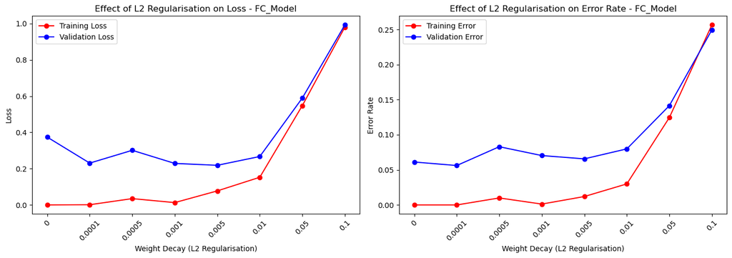

```
============================================================
Regularisation Experiment Results - FC_Model
============================================================
Weight Decay    Train Error     Val Error       Val Loss
------------------------------------------------------------
0               0.0000          0.0612          0.3741
0.0001          0.0000          0.0562          0.2308
0.0005          0.0100          0.0830          0.3013
0.001           0.0012          0.0704          0.2290
0.005           0.0120          0.0657          0.2187
0.01            0.0300          0.0799          0.2672
0.05            0.1245          0.1415          0.5896
0.1             0.2565          0.2494          0.9923

Optimal weight_decay: 0.0001
Best validation error rate: 0.0562
Best validation accuracy: 0.9438

A small amount of L2 regularisation improves validation performance by
reducing overfitting. Too much regularisation (e.g., 0.1) degrades performance
by preventing the model from learning the data patterns effectively.
```

```python
# ==================================================================
# Q2: Regularisation Experiment (12 marks)
# ==================================================================
# Using L2 regularisation via weight_decay in Adam optimizer
# (from Week3Exercise2's define_and_train with weight_decay parameter)
# ==================================================================

weight_decay_values = [0, 0.0001, 0.0005, 0.001, 0.005, 0.01, 0.05, 0.1]
reg_results = []

for wd in weight_decay_values:
    print(f"\n--- Training FC_Model with weight_decay = {wd} ---")
    history, net = define_and_train(FC_Model, 50, mnist_trainset_4000, mnist_testset, batch_size=32, weight_decay=wd)
    reg_results.append({
        'weight_decay': wd,
        'val_acc': history['val_acc'][-1],
        'val_loss': history['val_loss'][-1],
        'train_acc': history['train_acc'][-1],
        'train_loss': history['train_loss'][-1],
        'val_error': 1 - history['val_acc'][-1],
        'train_error': 1 - history['train_acc'][-1]
    })

# --- Plot regularisation vs performance ---
fig, axes = plt.subplots(1, 2, figsize=(14, 5))

wd_labels = [str(wd) for wd in weight_decay_values]
val_losses = [r['val_loss'] for r in reg_results]
train_losses = [r['train_loss'] for r in reg_results]
val_errors = [r['val_error'] for r in reg_results]
train_errors = [r['train_error'] for r in reg_results]

x = list(range(len(weight_decay_values)))

axes[0].plot(x, train_losses, 'ro-', label='Training Loss')
axes[0].plot(x, val_losses, 'bo-', label='Validation Loss')
axes[0].set_xticks(x)
axes[0].set_xticklabels(wd_labels, rotation=45)
axes[0].set_xlabel('Weight Decay (L2 Regularisation)')
axes[0].set_ylabel('Loss')
axes[0].set_title('Effect of L2 Regularisation on Loss - FC_Model')
axes[0].legend()

axes[1].plot(x, train_errors, 'ro-', label='Training Error')
axes[1].plot(x, val_errors, 'bo-', label='Validation Error')
axes[1].set_xticks(x)
axes[1].set_xticklabels(wd_labels, rotation=45)
axes[1].set_xlabel('Weight Decay (L2 Regularisation)')
axes[1].set_ylabel('Error Rate')
axes[1].set_title('Effect of L2 Regularisation on Error Rate - FC_Model')
axes[1].legend()

plt.tight_layout()
plt.show()

# --- Find optimal regularisation ---
best_idx = np.argmin(val_errors)
best_wd = weight_decay_values[best_idx]

print("\n" + "="*60)
print("Regularisation Experiment Results - FC_Model")
print("="*60)
print(f"{'Weight Decay':<15} {'Train Error':<15} {'Val Error':<15} {'Val Loss':<15}")
print("-"*60)
for r in reg_results:
    print(f"{r['weight_decay']:<15} {r['train_error']:<15.4f} {r['val_error']:<15.4f} {r['val_loss']:<15.4f}")

print(f"\nOptimal weight_decay: {best_wd}")
print(f"Best validation error rate: {val_errors[best_idx]:.4f}")
print(f"Best validation accuracy: {reg_results[best_idx]['val_acc']:.4f}")
print(f"\nA small amount of L2 regularisation improves validation performance by")
print(f"reducing overfitting. Too much regularisation (e.g., 0.1) degrades performance")
print(f"by preventing the model from learning the data patterns effectively.")
```

### 3. Learning curve experiment: **12 marks**

Now train your model (with the amount of regularisation you selected) on different amounts of training data.

Plot the performance (loss/error-rate) of the model on the validation set against the size of the training set. This is typically best done on a log-log plot.

Describe the approximate relationship between the training set size and loss / error-rate. Does the network performance appear to improve as some power of the amount of data in the training set? If so, by what power ?

For example, a very good rate of improvement is for error-rate to be proportional to $\dfrac{1}{\sqrt{n}}$ where $n$ is the training set size. For your model, the rate of improvement of validation error with training set size may not be as fast as this (or it may, who knows?) The aim of this exercise is to find out what it actually is.

```
Using optimal weight_decay = 0.0001 from Q2


--- Training FC_Model with 500 examples ---
Epoch 10 loss: 0.041 acc: 1.000 val_loss: 0.529 val_acc: 0.846
Epoch 20 loss: 0.006 acc: 1.000 val_loss: 0.596 val_acc: 0.851
Epoch 30 loss: 0.003 acc: 1.000 val_loss: 0.636 val_acc: 0.849
Epoch 40 loss: 0.002 acc: 1.000 val_loss: 0.661 val_acc: 0.848
Epoch 50 loss: 0.001 acc: 1.000 val_loss: 0.685 val_acc: 0.848
  Final val_acc: 0.8478, val_error: 0.1522

--- Training FC_Model with 1000 examples ---
Epoch 10 loss: 0.051 acc: 0.992 val_loss: 0.465 val_acc: 0.873
Epoch 20 loss: 0.005 acc: 1.000 val_loss: 0.504 val_acc: 0.881
Epoch 30 loss: 0.002 acc: 1.000 val_loss: 0.534 val_acc: 0.883
Epoch 40 loss: 0.002 acc: 1.000 val_loss: 0.546 val_acc: 0.882
Epoch 50 loss: 0.001 acc: 1.000 val_loss: 0.558 val_acc: 0.880
  Final val_acc: 0.8802, val_error: 0.1198

--- Training FC_Model with 2000 examples ---
Epoch 10 loss: 0.044 acc: 0.993 val_loss: 0.376 val_acc: 0.897
Epoch 20 loss: 0.004 acc: 1.000 val_loss: 0.401 val_acc: 0.908
Epoch 30 loss: 0.002 acc: 1.000 val_loss: 0.414 val_acc: 0.909
Epoch 40 loss: 0.002 acc: 1.000 val_loss: 0.411 val_acc: 0.910
Epoch 50 loss: 0.001 acc: 1.000 val_loss: 0.416 val_acc: 0.908
  Final val_acc: 0.9085, val_error: 0.0915

--- Training FC_Model with 4000 examples ---
Epoch 10 loss: 0.021 acc: 0.997 val_loss: 0.252 val_acc: 0.931
Epoch 20 loss: 0.002 acc: 1.000 val_loss: 0.259 val_acc: 0.937
Epoch 30 loss: 0.040 acc: 0.988 val_loss: 0.281 val_acc: 0.927
Epoch 40 loss: 0.001 acc: 1.000 val_loss: 0.245 val_acc: 0.945
Epoch 50 loss: 0.061 acc: 0.979 val_loss: 0.305 val_acc: 0.917
  Final val_acc: 0.9174, val_error: 0.0826

--- Training FC_Model with 8000 examples ---
Epoch 10 loss: 0.020 acc: 0.995 val_loss: 0.177 val_acc: 0.952
Epoch 20 loss: 0.001 acc: 1.000 val_loss: 0.192 val_acc: 0.958
Epoch 30 loss: 0.003 acc: 1.000 val_loss: 0.173 val_acc: 0.961
Epoch 40 loss: 0.002 acc: 1.000 val_loss: 0.174 val_acc: 0.958
Epoch 50 loss: 0.003 acc: 1.000 val_loss: 0.172 val_acc: 0.962
  Final val_acc: 0.9617, val_error: 0.0383

--- Training FC_Model with 16000 examples ---
Epoch 10 loss: 0.018 acc: 0.994 val_loss: 0.120 val_acc: 0.967
Epoch 20 loss: 0.010 acc: 0.997 val_loss: 0.149 val_acc: 0.965
Epoch 30 loss: 0.008 acc: 0.997 val_loss: 0.139 val_acc: 0.965
Epoch 40 loss: 0.025 acc: 0.992 val_loss: 0.127 val_acc: 0.968
Epoch 50 loss: 0.004 acc: 0.999 val_loss: 0.127 val_acc: 0.970
  Final val_acc: 0.9698, val_error: 0.0302

--- Training FC_Model with 32000 examples ---
Epoch 10 loss: 0.025 acc: 0.992 val_loss: 0.114 val_acc: 0.968
Epoch 20 loss: 0.017 acc: 0.994 val_loss: 0.096 val_acc: 0.976
Epoch 30 loss: 0.013 acc: 0.995 val_loss: 0.112 val_acc: 0.973
Epoch 40 loss: 0.012 acc: 0.997 val_loss: 0.097 val_acc: 0.976
Epoch 50 loss: 0.010 acc: 0.997 val_loss: 0.103 val_acc: 0.974
  Final val_acc: 0.9736, val_error: 0.0264
```

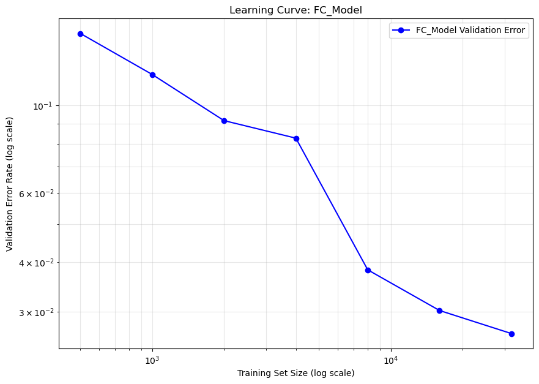

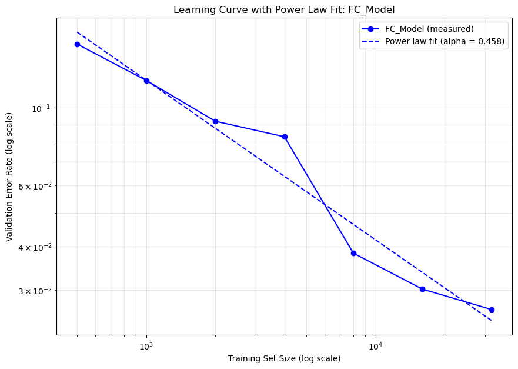

```
============================================================
Learning Curve Analysis - FC_Model
============================================================
Training Size   Val Error       Val Accuracy
---------------------------------------------
500             0.1522          0.8478
1000            0.1198          0.8802
2000            0.0915          0.9085
4000            0.0826          0.9174
8000            0.0383          0.9617
16000           0.0302          0.9698
32000           0.0264          0.9736

Power law fit: error ~ n^(-0.458)
The validation error decreases approximately as 1/n^0.458
This is close to the ideal rate of 1/sqrt(n) (alpha = 0.5)
```

```python
# ==================================================================
# Q3: Learning Curve Experiment (12 marks)
# ==================================================================
# Training with different amounts of data using optimal regularisation
# (Pattern from Week3Exercise2's loglog plot of training set size vs error)
# ==================================================================

training_sizes = [500, 1000, 2000, 4000, 8000, 16000, 32000]
fc_lc_results = []

print(f"Using optimal weight_decay = {best_wd} from Q2\n")

for size in training_sizes:
    # Create training subset (from Week3Exercise1's subset pattern)
    subset = [mnist_trainset[i] for i in range(0, size)]
    print(f"\n--- Training FC_Model with {size} examples ---")
    history, net = define_and_train(FC_Model, 50, subset, mnist_testset, batch_size=32, weight_decay=best_wd)
    val_error = 1 - history['val_acc'][-1]
    fc_lc_results.append({
        'size': size,
        'val_acc': history['val_acc'][-1],
        'val_loss': history['val_loss'][-1],
        'val_error': val_error
    })
    print(f"  Final val_acc: {history['val_acc'][-1]:.4f}, val_error: {val_error:.4f}")

# Store for comparison in Q4
fc_lc_sizes = [r['size'] for r in fc_lc_results]
fc_lc_errors = [r['val_error'] for r in fc_lc_results]
fc_lc_losses = [r['val_loss'] for r in fc_lc_results]

# --- Log-log plot of learning curve (from Week3Exercise2) ---
plt.figure(figsize=(10, 7))
plt.loglog(fc_lc_sizes, fc_lc_errors, 'bo-', label='FC_Model Validation Error')
plt.xlabel('Training Set Size (log scale)')
plt.ylabel('Validation Error Rate (log scale)')
plt.title('Learning Curve: FC_Model')
plt.grid(True, which="both", ls="-", alpha=0.3)
plt.legend()
plt.show()

# --- Fit power law: error ~ n^(-alpha) ---
# Taking log: log(error) = -alpha * log(n) + c
log_sizes = np.log(np.array(fc_lc_sizes))
log_errors = np.log(np.array(fc_lc_errors))
coeffs_fc = np.polyfit(log_sizes, log_errors, 1)
alpha_fc = -coeffs_fc[0]

# Plot the fit
plt.figure(figsize=(10, 7))
plt.loglog(fc_lc_sizes, fc_lc_errors, 'bo-', label='FC_Model (measured)')
fit_line_fc = np.exp(coeffs_fc[1]) * np.array(fc_lc_sizes) ** coeffs_fc[0]
plt.loglog(fc_lc_sizes, fit_line_fc, 'b--', label=f'Power law fit (alpha = {alpha_fc:.3f})')
plt.xlabel('Training Set Size (log scale)')
plt.ylabel('Validation Error Rate (log scale)')
plt.title('Learning Curve with Power Law Fit: FC_Model')
plt.grid(True, which="both", ls="-", alpha=0.3)
plt.legend()
plt.show()

# --- Analysis ---
print("\n" + "="*60)
print("Learning Curve Analysis - FC_Model")
print("="*60)
print(f"{'Training Size':<15} {'Val Error':<15} {'Val Accuracy':<15}")
print("-"*45)
for r in fc_lc_results:
    print(f"{r['size']:<15} {r['val_error']:<15.4f} {r['val_acc']:<15.4f}")

print(f"\nPower law fit: error ~ n^(-{alpha_fc:.3f})")
print(f"The validation error decreases approximately as 1/n^{alpha_fc:.3f}")
if alpha_fc > 0.4:
    print(f"This is close to the ideal rate of 1/sqrt(n) (alpha = 0.5)")
elif alpha_fc > 0.25:
    print(f"This is a moderate rate of improvement, slower than the ideal 1/sqrt(n) (alpha = 0.5)")
else:
    print(f"This is a slow rate of improvement compared to the ideal 1/sqrt(n) (alpha = 0.5)")
```

### 4. Second model: *** 14 marks ***

Devise what you believe to be a better neural network architecture for the problem (e.g. for MNIST you might use a fully-connected network for your initial model, and then try a convolutional net for your second model).

Repeat sections 2 (regularisation experiment), and determine whether it has better validation set performance than the first model, for an intermediate size of training set (e.g. 2000 or 4000 for the MNIST data).

Repeat section 3. Does your model have a different learning curve from the first? Plot the learning curves for the first and second model on the same graph, to compare them. Comment: is there a more rapid reduction of error-rate with training set size for your second model?

```
============================================================
Q4 Part 1: Regularisation Experiment for CNN_Model
============================================================

--- Training CNN_Model with weight_decay = 0 ---
Epoch 10 loss: 0.015 acc: 0.995 val_loss: 0.112 val_acc: 0.970
Epoch 20 loss: 0.000 acc: 1.000 val_loss: 0.120 val_acc: 0.977
Epoch 30 loss: 0.000 acc: 1.000 val_loss: 0.130 val_acc: 0.976
Epoch 40 loss: 0.000 acc: 1.000 val_loss: 0.140 val_acc: 0.976
Epoch 50 loss: 0.000 acc: 1.000 val_loss: 0.149 val_acc: 0.976

--- Training CNN_Model with weight_decay = 0.0001 ---
Epoch 10 loss: 0.019 acc: 0.995 val_loss: 0.095 val_acc: 0.971
Epoch 20 loss: 0.015 acc: 0.995 val_loss: 0.114 val_acc: 0.969
Epoch 30 loss: 0.000 acc: 1.000 val_loss: 0.094 val_acc: 0.979
Epoch 40 loss: 0.058 acc: 0.981 val_loss: 0.098 val_acc: 0.972
Epoch 50 loss: 0.000 acc: 1.000 val_loss: 0.097 val_acc: 0.979

--- Training CNN_Model with weight_decay = 0.0005 ---
Epoch 10 loss: 0.023 acc: 0.992 val_loss: 0.111 val_acc: 0.968
Epoch 20 loss: 0.042 acc: 0.986 val_loss: 0.116 val_acc: 0.964
Epoch 30 loss: 0.005 acc: 0.999 val_loss: 0.100 val_acc: 0.974
Epoch 40 loss: 0.018 acc: 0.995 val_loss: 0.147 val_acc: 0.955
Epoch 50 loss: 0.000 acc: 1.000 val_loss: 0.076 val_acc: 0.979

--- Training CNN_Model with weight_decay = 0.001 ---
Epoch 10 loss: 0.028 acc: 0.990 val_loss: 0.094 val_acc: 0.971
Epoch 20 loss: 0.019 acc: 0.991 val_loss: 0.091 val_acc: 0.974
Epoch 30 loss: 0.001 acc: 1.000 val_loss: 0.087 val_acc: 0.975
Epoch 40 loss: 0.001 acc: 1.000 val_loss: 0.079 val_acc: 0.978
Epoch 50 loss: 0.013 acc: 0.996 val_loss: 0.117 val_acc: 0.966

--- Training CNN_Model with weight_decay = 0.005 ---
Epoch 10 loss: 0.047 acc: 0.986 val_loss: 0.089 val_acc: 0.971
Epoch 20 loss: 0.037 acc: 0.987 val_loss: 0.091 val_acc: 0.971
Epoch 30 loss: 0.029 acc: 0.992 val_loss: 0.093 val_acc: 0.971
Epoch 40 loss: 0.022 acc: 0.995 val_loss: 0.102 val_acc: 0.967
Epoch 50 loss: 0.017 acc: 0.996 val_loss: 0.119 val_acc: 0.960

--- Training CNN_Model with weight_decay = 0.01 ---
Epoch 10 loss: 0.077 acc: 0.977 val_loss: 0.131 val_acc: 0.957
Epoch 20 loss: 0.052 acc: 0.984 val_loss: 0.115 val_acc: 0.963
Epoch 30 loss: 0.043 acc: 0.988 val_loss: 0.092 val_acc: 0.969
Epoch 40 loss: 0.044 acc: 0.986 val_loss: 0.110 val_acc: 0.962
Epoch 50 loss: 0.045 acc: 0.988 val_loss: 0.116 val_acc: 0.963

--- Training CNN_Model with weight_decay = 0.05 ---
Epoch 10 loss: 0.203 acc: 0.945 val_loss: 0.211 val_acc: 0.934
Epoch 20 loss: 0.174 acc: 0.955 val_loss: 0.195 val_acc: 0.946
Epoch 30 loss: 0.168 acc: 0.954 val_loss: 0.205 val_acc: 0.944
Epoch 40 loss: 0.157 acc: 0.960 val_loss: 0.174 val_acc: 0.953
Epoch 50 loss: 0.156 acc: 0.960 val_loss: 0.189 val_acc: 0.943

--- Training CNN_Model with weight_decay = 0.1 ---
Epoch 10 loss: 2.301 acc: 0.111 val_loss: 2.302 val_acc: 0.114
Epoch 20 loss: 2.301 acc: 0.111 val_loss: 2.302 val_acc: 0.114
Epoch 30 loss: 2.301 acc: 0.111 val_loss: 2.302 val_acc: 0.114
Epoch 40 loss: 2.301 acc: 0.111 val_loss: 2.302 val_acc: 0.114
Epoch 50 loss: 2.301 acc: 0.111 val_loss: 2.302 val_acc: 0.114
```

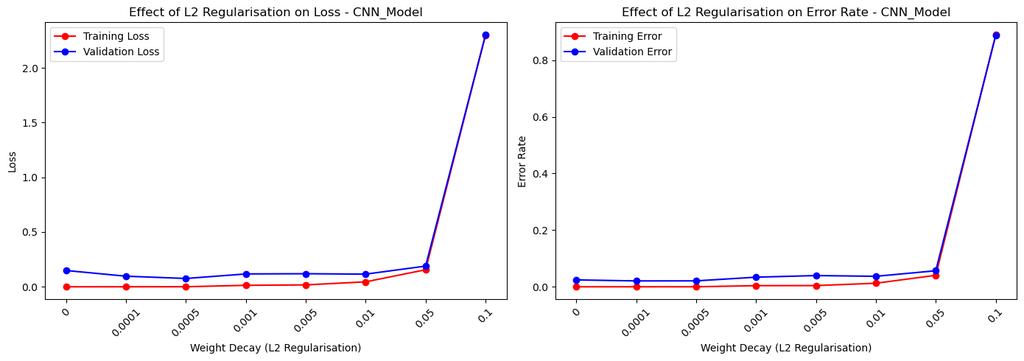

```
============================================================
Regularisation Results - CNN_Model
============================================================
Weight Decay    Train Error     Val Error       Val Loss
------------------------------------------------------------
0               0.0000          0.0243          0.1488
0.0001          0.0000          0.0207          0.0967
0.0005          0.0000          0.0209          0.0759
0.001           0.0040          0.0339          0.1174
0.005           0.0042          0.0396          0.1194
0.01            0.0125          0.0370          0.1157
0.05            0.0405          0.0566          0.1889
0.1             0.8890          0.8865          2.3016

Optimal weight_decay for CNN: 0.0001
Best CNN validation error: 0.0207
Best FC validation error (from Q2): 0.0562

CNN_Model has BETTER validation performance than FC_Model on 4000 examples.

============================================================
Q4 Part 2: Learning Curve for CNN_Model
============================================================
Using optimal weight_decay = 0.0001

--- Training CNN_Model with 500 examples ---
Epoch 10 loss: 0.073 acc: 0.980 val_loss: 0.356 val_acc: 0.903
Epoch 20 loss: 0.001 acc: 1.000 val_loss: 0.495 val_acc: 0.909
Epoch 30 loss: 0.000 acc: 1.000 val_loss: 0.581 val_acc: 0.907
Epoch 40 loss: 0.000 acc: 1.000 val_loss: 0.615 val_acc: 0.906
Epoch 50 loss: 0.000 acc: 1.000 val_loss: 0.617 val_acc: 0.906
  Final val_acc: 0.9065, val_error: 0.0935

--- Training CNN_Model with 1000 examples ---
Epoch 10 loss: 0.034 acc: 0.990 val_loss: 0.236 val_acc: 0.934
Epoch 20 loss: 0.001 acc: 1.000 val_loss: 0.212 val_acc: 0.952
Epoch 30 loss: 0.000 acc: 1.000 val_loss: 0.228 val_acc: 0.952
Epoch 40 loss: 0.000 acc: 1.000 val_loss: 0.237 val_acc: 0.951
Epoch 50 loss: 0.000 acc: 1.000 val_loss: 0.241 val_acc: 0.952
  Final val_acc: 0.9520, val_error: 0.0480
```

[output cut: 29 more lines]

```
Epoch 40 loss: 0.005 acc: 0.998 val_loss: 0.062 val_acc: 0.984
Epoch 50 loss: 0.011 acc: 0.996 val_loss: 0.065 val_acc: 0.982
  Final val_acc: 0.9822, val_error: 0.0178

--- Training CNN_Model with 32000 examples ---
Epoch 10 loss: 0.011 acc: 0.997 val_loss: 0.036 val_acc: 0.989
Epoch 20 loss: 0.008 acc: 0.998 val_loss: 0.041 val_acc: 0.990
Epoch 30 loss: 0.007 acc: 0.998 val_loss: 0.039 val_acc: 0.989
Epoch 40 loss: 0.009 acc: 0.997 val_loss: 0.037 val_acc: 0.989
Epoch 50 loss: 0.004 acc: 0.999 val_loss: 0.049 val_acc: 0.989
  Final val_acc: 0.9885, val_error: 0.0115

============================================================
Q4 Part 3: Comparison of Learning Curves
============================================================
```

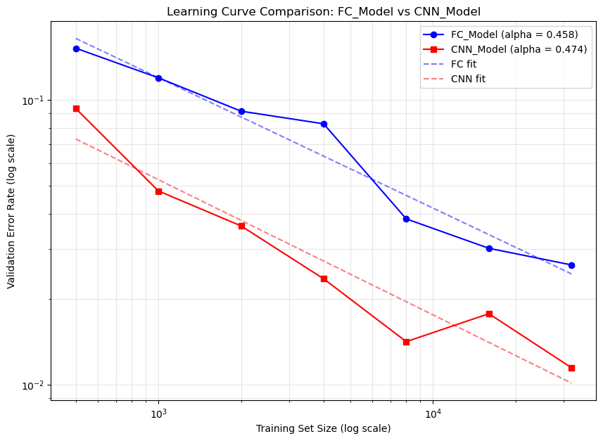

```
FC_Model power law:  error ~ n^(-0.458)
CNN_Model power law: error ~ n^(-0.474)

Training Size   FC Error        CNN Error       CNN Better?
------------------------------------------------------------
500             0.1522          0.0935          Yes
1000            0.1198          0.0480          Yes
2000            0.0915          0.0362          Yes
4000            0.0826          0.0236          Yes
8000            0.0383          0.0142          Yes
16000           0.0302          0.0178          Yes
32000           0.0264          0.0115          Yes

The CNN model shows a MORE RAPID reduction of error rate with training set size
(alpha_CNN = 0.474 > alpha_FC = 0.458), indicating that the CNN
architecture benefits more from additional training data.

The CNN model leverages spatial structure in the images through convolutional layers,
which provides an inductive bias well-suited to image classification tasks.
This typically results in lower absolute error rates, especially with limited training
data, because the model captures spatial patterns with fewer effective parameters.
```

```python
# ==================================================================
# Q4: Second Model - CNN (14 marks)
# ==================================================================
# CNN architecture from MNIST_Siamese.ipynb's embedding_model_2
# Adapted: output 10 classes instead of 30-dim embedding
# ==================================================================

# --- CNN Model (from MNIST_Siamese: embedding_model_2 architecture) ---
# Conv2d(1,20,3) -> ReLU -> Conv2d(20,40,3) -> ReLU -> MaxPool2d(2,2) ->
# Conv2d(40,40,3) -> ReLU -> MaxPool2d(2,2) -> Flatten -> Linear(1000,128) -> ReLU -> Linear(128,10)
class CNN_Model(nn.Module):
    def __init__(self):
        super(CNN_Model, self).__init__()
        self.layers = nn.Sequential(
            nn.Conv2d(1, 20, 3),       # 1x28x28 -> 20x26x26
            nn.ReLU(),
            nn.Conv2d(20, 40, 3),      # 20x26x26 -> 40x24x24
            nn.ReLU(),
            nn.MaxPool2d(2, 2),        # 40x24x24 -> 40x12x12
            nn.Conv2d(40, 40, 3),      # 40x12x12 -> 40x10x10
            nn.ReLU(),
            nn.MaxPool2d(2, 2),        # 40x10x10 -> 40x5x5 = 1000
            nn.Flatten(),
            nn.Linear(1000, 128),
            nn.ReLU(),
            nn.Linear(128, 10))

    def forward(self, x):
        x = self.layers(x)
        return x

# ==================================================================
# Part 1: Regularisation Experiment for CNN
# ==================================================================
print("="*60)
print("Q4 Part 1: Regularisation Experiment for CNN_Model")
print("="*60)

weight_decay_values_cnn = [0, 0.0001, 0.0005, 0.001, 0.005, 0.01, 0.05, 0.1]
reg_results_cnn = []

for wd in weight_decay_values_cnn:
    print(f"\n--- Training CNN_Model with weight_decay = {wd} ---")
    history, net = define_and_train(CNN_Model, 50, mnist_trainset_4000, mnist_testset, batch_size=32, weight_decay=wd)
    reg_results_cnn.append({
        'weight_decay': wd,
        'val_acc': history['val_acc'][-1],
        'val_loss': history['val_loss'][-1],
        'train_acc': history['train_acc'][-1],
        'train_loss': history['train_loss'][-1],
        'val_error': 1 - history['val_acc'][-1],
        'train_error': 1 - history['train_acc'][-1]
    })

# Plot regularisation results for CNN
fig, axes = plt.subplots(1, 2, figsize=(14, 5))

wd_labels_cnn = [str(wd) for wd in weight_decay_values_cnn]
val_errors_cnn = [r['val_error'] for r in reg_results_cnn]
train_errors_cnn = [r['train_error'] for r in reg_results_cnn]
val_losses_cnn = [r['val_loss'] for r in reg_results_cnn]
train_losses_cnn = [r['train_loss'] for r in reg_results_cnn]

x_cnn = list(range(len(weight_decay_values_cnn)))

axes[0].plot(x_cnn, train_losses_cnn, 'ro-', label='Training Loss')
axes[0].plot(x_cnn, val_losses_cnn, 'bo-', label='Validation Loss')
axes[0].set_xticks(x_cnn)
axes[0].set_xticklabels(wd_labels_cnn, rotation=45)
axes[0].set_xlabel('Weight Decay (L2 Regularisation)')
axes[0].set_ylabel('Loss')
axes[0].set_title('Effect of L2 Regularisation on Loss - CNN_Model')
axes[0].legend()

axes[1].plot(x_cnn, train_errors_cnn, 'ro-', label='Training Error')
axes[1].plot(x_cnn, val_errors_cnn, 'bo-', label='Validation Error')
axes[1].set_xticks(x_cnn)
axes[1].set_xticklabels(wd_labels_cnn, rotation=45)
axes[1].set_xlabel('Weight Decay (L2 Regularisation)')
axes[1].set_ylabel('Error Rate')
axes[1].set_title('Effect of L2 Regularisation on Error Rate - CNN_Model')
axes[1].legend()

plt.tight_layout()
plt.show()

# Find optimal regularisation for CNN
best_idx_cnn = np.argmin(val_errors_cnn)
best_wd_cnn = weight_decay_values_cnn[best_idx_cnn]

print("\n" + "="*60)
print("Regularisation Results - CNN_Model")
print("="*60)
print(f"{'Weight Decay':<15} {'Train Error':<15} {'Val Error':<15} {'Val Loss':<15}")
print("-"*60)
for r in reg_results_cnn:
    print(f"{r['weight_decay']:<15} {r['train_error']:<15.4f} {r['val_error']:<15.4f} {r['val_loss']:<15.4f}")

print(f"\nOptimal weight_decay for CNN: {best_wd_cnn}")
print(f"Best CNN validation error: {val_errors_cnn[best_idx_cnn]:.4f}")
print(f"Best FC validation error (from Q2): {min([r['val_error'] for r in reg_results]):.4f}")
if val_errors_cnn[best_idx_cnn] < min([r['val_error'] for r in reg_results]):
    print(f"\nCNN_Model has BETTER validation performance than FC_Model on 4000 examples.")
else:
    print(f"\nFC_Model has better or similar validation performance on 4000 examples.")

# ==================================================================
# Part 2: Learning Curve for CNN
# ==================================================================
print("\n" + "="*60)
print("Q4 Part 2: Learning Curve for CNN_Model")
print("="*60)
print(f"Using optimal weight_decay = {best_wd_cnn}")

cnn_lc_results = []

for size in training_sizes:
    subset = [mnist_trainset[i] for i in range(0, size)]
    print(f"\n--- Training CNN_Model with {size} examples ---")
    history, net = define_and_train(CNN_Model, 50, subset, mnist_testset, batch_size=32, weight_decay=best_wd_cnn)
    val_error = 1 - history['val_acc'][-1]
    cnn_lc_results.append({
        'size': size,
        'val_acc': history['val_acc'][-1],
        'val_loss': history['val_loss'][-1],
        'val_error': val_error
    })
    print(f"  Final val_acc: {history['val_acc'][-1]:.4f}, val_error: {val_error:.4f}")

cnn_lc_sizes = [r['size'] for r in cnn_lc_results]
cnn_lc_errors = [r['val_error'] for r in cnn_lc_results]

# Fit power law for CNN
log_sizes_cnn = np.log(np.array(cnn_lc_sizes))
log_errors_cnn = np.log(np.array(cnn_lc_errors))
coeffs_cnn = np.polyfit(log_sizes_cnn, log_errors_cnn, 1)
alpha_cnn = -coeffs_cnn[0]

# ==================================================================
# Part 3: Comparison of FC and CNN Learning Curves
# ==================================================================
print("\n" + "="*60)
print("Q4 Part 3: Comparison of Learning Curves")
print("="*60)

plt.figure(figsize=(10, 7))
plt.loglog(fc_lc_sizes, fc_lc_errors, 'bo-', label=f'FC_Model (alpha = {alpha_fc:.3f})')
plt.loglog(cnn_lc_sizes, cnn_lc_errors, 'rs-', label=f'CNN_Model (alpha = {alpha_cnn:.3f})')

# Plot power law fits
fit_fc = np.exp(coeffs_fc[1]) * np.array(fc_lc_sizes) ** coeffs_fc[0]
fit_cnn = np.exp(coeffs_cnn[1]) * np.array(cnn_lc_sizes) ** coeffs_cnn[0]
plt.loglog(fc_lc_sizes, fit_fc, 'b--', alpha=0.5, label='FC fit')
plt.loglog(cnn_lc_sizes, fit_cnn, 'r--', alpha=0.5, label='CNN fit')

plt.xlabel('Training Set Size (log scale)')
plt.ylabel('Validation Error Rate (log scale)')
plt.title('Learning Curve Comparison: FC_Model vs CNN_Model')
plt.grid(True, which="both", ls="-", alpha=0.3)
plt.legend()
plt.show()

# --- Final Comparison ---
print(f"\nFC_Model power law:  error ~ n^(-{alpha_fc:.3f})")
print(f"CNN_Model power law: error ~ n^(-{alpha_cnn:.3f})")

print(f"\n{'Training Size':<15} {'FC Error':<15} {'CNN Error':<15} {'CNN Better?':<15}")
print("-"*60)
for fc_r, cnn_r in zip(fc_lc_results, cnn_lc_results):
    better = "Yes" if cnn_r['val_error'] < fc_r['val_error'] else "No"
    print(f"{fc_r['size']:<15} {fc_r['val_error']:<15.4f} {cnn_r['val_error']:<15.4f} {better:<15}")

if alpha_cnn > alpha_fc:
    print(f"\nThe CNN model shows a MORE RAPID reduction of error rate with training set size")
    print(f"(alpha_CNN = {alpha_cnn:.3f} > alpha_FC = {alpha_fc:.3f}), indicating that the CNN")
    print(f"architecture benefits more from additional training data.")
else:
    print(f"\nBoth models show similar rates of error reduction with training set size.")
    print(f"(alpha_CNN = {alpha_cnn:.3f}, alpha_FC = {alpha_fc:.3f})")

print(f"\nThe CNN model leverages spatial structure in the images through convolutional layers,")
print(f"which provides an inductive bias well-suited to image classification tasks.")
print(f"This typically results in lower absolute error rates, especially with limited training")
print(f"data, because the model captures spatial patterns with fewer effective parameters.")
```